# MSDS 596 Final Project

Group of Sean Heon Park / Kai-en Huang / Meiqiao Shi / Michael Ryvin

# MSDS 596 Final Project

## Analysis of Student Alcohol Consumption

### Summary of the Data

The data being used comes specifically from Portuguese classes only.

| school | sex | age | address | famsize | Pstatus | Medu | Fedu | Mjob | Fjob | reason | guardian |
| --- | --- | --- | --- | --- | --- | --- | --- | --- | --- | --- | --- |
| GP | F | 18 | U | GT3 | A | 4 | 4 | at_home | teacher | course | mother |
| GP | F | 17 | U | GT3 | T | 1 | 1 | at_home | other | course | father |
| GP | F | 15 | U | LE3 | T | 1 | 1 | at_home | other | other | mother |
| GP | F | 15 | U | GT3 | T | 4 | 2 | health | services | home | mother |
| GP | F | 16 | U | GT3 | T | 3 | 3 | other | other | home | father |
| GP | M | 16 | U | LE3 | T | 4 | 3 | services | other | reputation | mother |

| traveltime | studytime | failures | schoolsup | famsup | paid | activities | nursery | higher | internet | romantic |
| --- | --- | --- | --- | --- | --- | --- | --- | --- | --- | --- |
| 2 | 2 | 0 | yes | no | no | no | yes | yes | no | no |
| 1 | 2 | 0 | no | yes | no | no | no | yes | yes | no |
| 1 | 2 | 0 | yes | no | no | no | yes | yes | yes | no |
| 1 | 3 | 0 | no | yes | no | yes | yes | yes | yes | yes |
| 1 | 2 | 0 | no | yes | no | no | yes | yes | no | no |
| 1 | 2 | 0 | no | yes | no | yes | yes | yes | yes | no |

| romantic | famrel | freetime | goout | Dalc | Walc | health | absences | G1 | G2 | G3 |
| --- | --- | --- | --- | --- | --- | --- | --- | --- | --- | --- |
| no | 4 | 3 | 4 | 1 | 1 | 3 | 4 | 0 | 11 | 11 |
| no | 5 | 3 | 3 | 1 | 1 | 3 | 2 | 9 | 11 | 11 |
| no | 4 | 3 | 2 | 2 | 3 | 3 | 6 | 12 | 13 | 12 |
| yes | 3 | 2 | 2 | 1 | 1 | 5 | 0 | 14 | 14 | 14 |
| no | 4 | 3 | 2 | 1 | 2 | 5 | 0 | 11 | 13 | 13 |
| no | 5 | 4 | 2 | 1 | 2 | 5 | 6 | 12 | 12 | 13 |

The data contains 33 columns. Their meanings are listed as follows:

- **school**: Student’s school (binary: ‘GP’ - Gabriel Pereira or ‘MS’ - Mousinho da Silveira)
- **sex**: Student’s sex (binary: ‘F’ - female or ‘M’ - male)
- **age**: Student’s age (numeric: from 15 to 22)
- **address**: Student’s home address type (binary: ‘U’ - urban or ‘R’ - rural)
- **famsize**: Family size (binary: ‘LE3’ - less or equal to 3 or ‘GT3’ - greater than 3)
- **Pstatus**: Parent’s cohabitation status (binary: ‘T’ - living together or ‘A’ - apart)
- **Medu**: Mother’s education (numeric: 0 - none, 1 - primary education (4th grade), 2 – 5th to 9th grade, 3 – secondary education, or 4 – higher education)
- **Fedu**: Father’s education (numeric: 0 - none, 1 - primary education (4th grade), 2 – 5th to 9th grade, 3 – secondary education, or 4 – higher education)
- **Mjob**: Mother’s job (nominal: ‘teacher’, ‘health’ care related, civil ‘services’ (e.g., administrative or police), ‘at_home’, or ‘other’)
- **Fjob**: Father’s job (nominal: ‘teacher’, ‘health’ care related, civil ‘services’ (e.g., administrative or police), ‘at_home’, or ‘other’)
- **reason**: Reason to choose this school (nominal: close to ‘home’, school ‘reputation’, ‘course’ preference, or ‘other’)
- **guardian**: Student’s guardian (nominal: ‘mother’, ‘father’ or ‘other’)
- **traveltime**: Home to school travel time (numeric: 1 - <15 min., 2 - 15 to 30 min., 3 - 30 min. to 1 hour, or 4 - >1 hour)
- **studytime**: Weekly study time (numeric: 1 - <2 hours, 2 - 2 to 5 hours, 3 - 5 to 10 hours, or 4 - >10 hours)
- **failures**: Number of past class failures (numeric: n if 1<=n<3, else 4)
- **schoolsup**: Extra educational support (binary: yes or no)
- **famsup**: Family educational support (binary: yes or no)
- **paid**: Extra paid classes within the course subject (Math or Portuguese) (binary: yes or no)
- **activities**: Extra-curricular activities (binary: yes or no)
- **nursery**: Attended nursery school (binary: yes or no)
- **higher**: Wants to take higher education (binary: yes or no)
- **internet**: Internet access at home (binary: yes or no)
- **romantic**: With a romantic relationship (binary: yes or no)
- **famrel**: Quality of family relationships (numeric: from 1 - very bad to 5 - excellent)
- **freetime**: Free time after school (numeric: from 1 - very low to 5 - very high)
- **goout**: Going out with friends (numeric: from 1 - very low to 5 - very high)
- **Dalc**: Workday alcohol consumption (numeric: from 1 - very low to 5 - very high)
- **Walc**: Weekend alcohol consumption (numeric: from 1 - very low to 5 - very high)
- **health**: Current health status (numeric: from 1 - very bad to 5 - very good)
- **absences**: Number of school absences (numeric: from 0 to 93)
- **G1**: First period grade (numeric: from 0 to 20)
- **G2**: Second period grade (numeric: from 0 to 20)
- **G3**: Final grade (numeric: from 0 to 20, output target)

**Creating a Total Alcohol Consumption Column**

Currently, total alcohol consumption is split into weekday and weekend alcohol consumption. In order to conduct the rest of the analysis on total alcohol consumption, we made a new column combining the two. Since the values were based on a low to high scale and couldnt necessarily be added directly, we combined them by multiplying them by the amount of days they counted for (5 weekdays and 2 weekends).

```r
d1$Talc <- ((5/7) * d1$Dalc) + ((2/7) * d1$Walc)
d1$Walc <- NULL
d1$Dalc <- NULL
```

##### Figure 1

We next wanted to look at the values that each of the variables have. All categorical variables were converted into factors and all numerical variables were converted to numeric values in order to see various statistics about them. Although some numeric values could have been viewed as factors, we chose to view them as numerical as it would be more important to look at averages for these rather than counts of the individual values those variables had. The variable statistics are all listed below:

| skim_variable | n_missing | factor.n_unique | factor.top_counts |
| --- | --- | --- | --- |
| school | 0 | 2 | GP: 423, MS: 226 |
| sex | 0 | 2 | F: 383, M: 266 |
| address | 0 | 2 | U: 452, R: 197 |
| famsize | 0 | 2 | GT3: 457, LE3: 192 |
| Pstatus | 0 | 2 | T: 569, A: 80 |
| Mjob | 0 | 5 | oth: 258, ser: 136, at_: 135, tea: 72 |
| Fjob | 0 | 5 | oth: 367, ser: 181, at_: 42, tea: 36 |
| reason | 0 | 4 | cou: 285, hom: 149, rep: 143, oth: 72 |
| guardian | 0 | 3 | mot: 455, fat: 153, oth: 41 |
| schoolsup | 0 | 2 | no: 581, yes: 68 |
| famsup | 0 | 2 | yes: 398, no: 251 |
| paid | 0 | 2 | no: 610, yes: 39 |
| activities | 0 | 2 | no: 334, yes: 315 |
| nursery | 0 | 2 | yes: 521, no: 128 |
| higher | 0 | 2 | yes: 580, no: 69 |
| internet | 0 | 2 | yes: 498, no: 151 |
| romantic | 0 | 2 | no: 410, yes: 239 |

| skim_variable | n_missing | numeric.mean | numeric.sd | numeric.p0 | numeric.p25 | numeric.p50 | numeric.p75 | numeric.p100 | numeric.hist |
| --- | --- | --- | --- | --- | --- | --- | --- | --- | --- |
| age | 0 | 16.7442219 | 1.2181376 | 15 | 16 | 17.000000 | 18.000000 | 22 | ▇▅▅▁▁ |
| Medu | 0 | 2.5146379 | 1.1345520 | 0 | 2 | 2.000000 | 4.000000 | 4 | ▁▆▇▆▇ |
| Fedu | 0 | 2.3066256 | 1.0999309 | 0 | 1 | 2.000000 | 3.000000 | 4 | ▁▆▇▅▅ |
| traveltime | 0 | 1.5685670 | 0.7486601 | 1 | 1 | 1.000000 | 2.000000 | 4 | ▇▅▁▁▁ |
| studytime | 0 | 1.9306626 | 0.8295096 | 1 | 1 | 2.000000 | 2.000000 | 4 | ▆▇▁▂▁ |
| failures | 0 | 0.2218798 | 0.5932351 | 0 | 0 | 0.000000 | 0.000000 | 3 | ▇▁▁▁▁ |
| famrel | 0 | 3.9306626 | 0.9557169 | 1 | 4 | 4.000000 | 5.000000 | 5 | ▁▁▂▇▅ |
| freetime | 0 | 3.1802773 | 1.0510926 | 1 | 3 | 3.000000 | 4.000000 | 5 | ▂▃▇▆▂ |
| goout | 0 | 3.1848998 | 1.1757661 | 1 | 2 | 3.000000 | 4.000000 | 5 | ▂▆▇▆▅ |
| health | 0 | 3.5362096 | 1.4462591 | 1 | 2 | 4.000000 | 5.000000 | 5 | ▃▂▃▃▇ |
| absences | 0 | 3.6594761 | 4.6407588 | 0 | 0 | 2.000000 | 6.000000 | 32 | ▇▂▁▁▁ |
| G1 | 0 | 11.3990755 | 2.7452651 | 0 | 10 | 11.000000 | 13.000000 | 19 | ▁▂▇▇▁ |
| G2 | 0 | 11.5701079 | 2.9136387 | 0 | 10 | 11.000000 | 13.000000 | 19 | ▁▁▇▇▂ |
| G3 | 0 | 11.9060092 | 3.2306562 | 0 | 10 | 12.000000 | 14.000000 | 19 | ▁▁▇▇▂ |
| Talc | 0 | 1.7246313 | 0.9327270 | 1 | 1 | 1.285714 | 2.142857 | 5 | ▇▃▁▁▁ |

##### Categorical Data Observations

- **School**: There are two schools represented, with **GP** having 423 entries and **MS** having 226.
- **Sex**: The dataset includes 383 females (**F**) and 266 males (**M**).
- **Address**: 452 students have an urban (**U**) address, while 197 have a rural (**R**) address.
- **Family Size**: Most students come from families with more than 3 members (**GT3**: 457), compared to 192 with 3 or fewer (**LE3**).
- **Parental Status**: A large majority of students have parents living together (**T**: 569), with only 80 having parents living apart (**A**).
- **Mother’s Job** (`Mjob`): The most common job category for mothers is ‘other’ (**oth**: 258), followed by ‘services’ (**ser**: 136), ‘at_home’ (**at_**: 135), and ‘teacher’ (**tea**: 72).
- **Father’s Job** (`Fjob`): Similarly, the most common job category for fathers is also ‘other’ (**oth**: 367), with ‘services’ (**ser**: 181) being the second most common.
- **Reason for Choosing School**: The top reason for choosing a school is its course offerings (**cou**: 285), followed by proximity to home (**hom**: 149), reputation (**rep**: 143), and ‘other’ reasons (**oth**: 72).
- **Guardian**: The majority of students have their mother as a guardian (**mot**: 455), with fathers (**fat**: 153) and others (**oth**: 41) being less common.
- **School Support**: Most students do not receive extra educational support at school (**no**: 581), while a minority do (**yes**: 68).
- **Family Support**: More students receive family support (**yes**: 398) than those who do not (**no**: 251).
- **Paid Classes**: A vast majority of students do not take paid classes outside of school (**no**: 610), with only 39 doing so (**yes**).
- **Activities**: The dataset is almost evenly split between students who participate in extra-curricular activities (**yes**: 315) and those who do not (**no**: 334).
- **Nursery School**: Most students attended nursery school (**yes**: 521), while a smaller number did not (**no**: 128).
- **Higher Education Aspirations**: Almost all students plan to pursue higher education (**yes**: 580), with a small number indicating otherwise (**no**: 69).
- **Internet Access**: A majority of students have internet access at home (**yes**: 498), compared to those who do not (**no**: 151).
- **Romantic Relationships**: More students are not in a romantic relationship (**no**: 410) than those who are (**yes**: 239).

### Visualizing the Data

##### Figure 2. Histogram of Total Alcohol Consumption

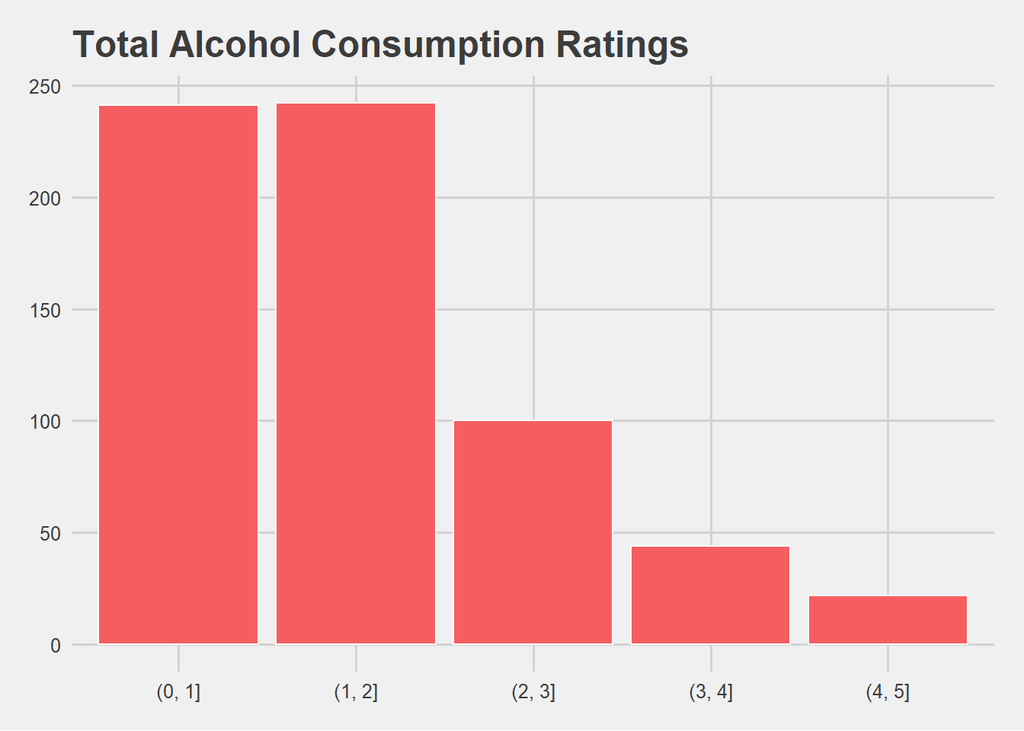

The histogram above show the distribution of Total Alcohol Consumption ratings put into buckets ranging from 0-1, 1-2, 2-3, 3-4, and 4-5. We can see that the majority of the ratings are concentrated at lower ratings, with few people having alcohol consumption ratings over 4.

##### Figure 3. Boxplot Analysis

Below are the boxplots showing the alcohol consumption scores across every variable. These are used to determine which categorical variables (or numerical variables turned into categorical variables) should be used in the regression model.

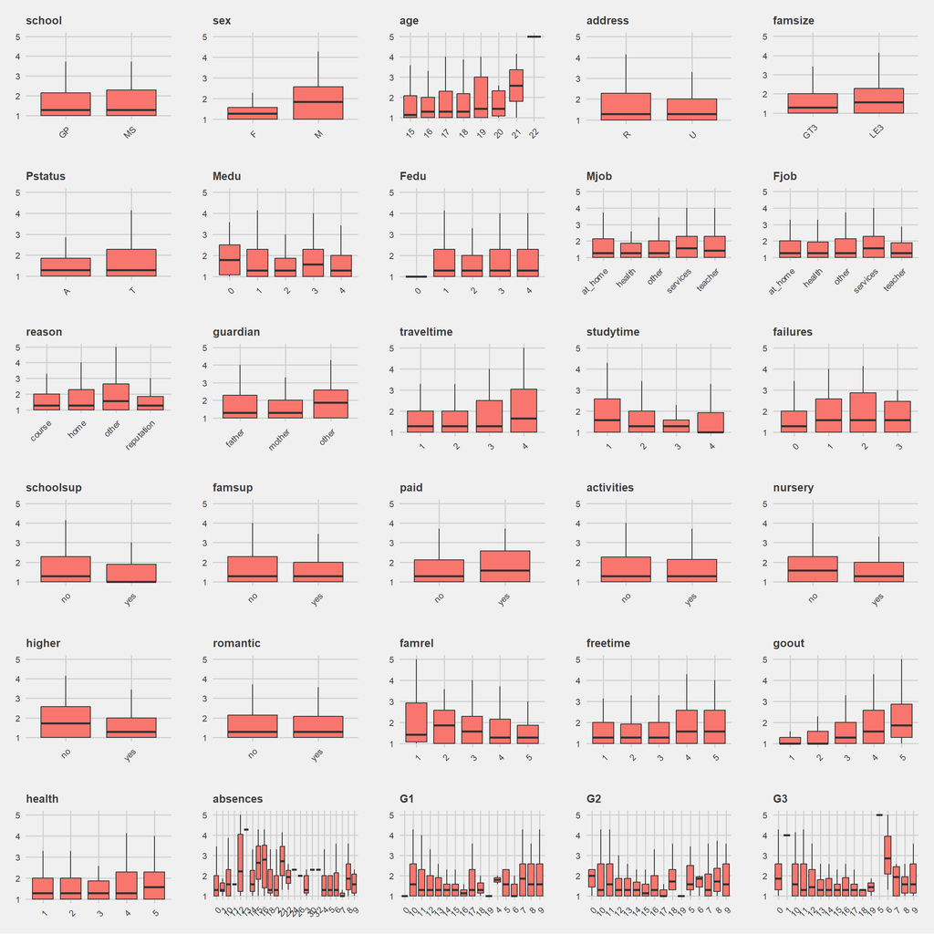

By inspecting the boxplots, we see some variables have more differences between their boxplots than others. However, to get further information, we can try looking at the p-values and R-squared values we get when doing one variable models with total alcohol consumption and treating the independent variables as factors. These values are as follows:

| Variable | P_Value | R_Squared |
| --- | --- | --- |
| school | 0.3214181 | 0.0015196 |
| sex | 0.0000000 | 0.1065529 |
| age | 0.5185312 | 0.0341885 |
| address | 0.3288534 | 0.0014736 |
| famsize | 0.0559115 | 0.0056371 |
| Pstatus | 0.1446251 | 0.0032862 |
| Medu | 0.7425176 | 0.0145872 |
| Fedu | 0.0314862 | 0.0083217 |
| Mjob | 0.3827864 | 0.0060484 |
| Fjob | 0.6212203 | 0.0130435 |
| reason | 0.1483275 | 0.0183235 |
| guardian | 0.2998895 | 0.0078416 |
| traveltime | 0.7077132 | 0.0109947 |
| studytime | 0.0000041 | 0.0489554 |
| failures | 0.0153483 | 0.0136573 |
| schoolsup | 0.1362310 | 0.0034280 |
| famsup | 0.3370790 | 0.0014244 |
| paid | 0.1956864 | 0.0025864 |
| activities | 0.4621254 | 0.0008361 |
| nursery | 0.0297712 | 0.0072780 |
| higher | 0.0012487 | 0.0159835 |
| internet | 0.1679924 | 0.0029358 |
| romantic | 0.3587364 | 0.0013020 |
| famrel | 0.8144617 | 0.0097455 |
| freetime | 0.4151561 | 0.0271906 |
| goout | 0.2893655 | 0.1122190 |
| health | 0.9824371 | 0.0080541 |
| absences | 0.6241657 | 0.0761004 |
| G1 | 0.4840289 | 0.0590538 |
| G2 | 0.8708920 | 0.0712657 |
| G3 | 0.0408723 | 0.0917775 |

##### Figure 4. Correlation Table

Below we will use a correlation table to quickly examine any correlations that Talc may have with other variables.

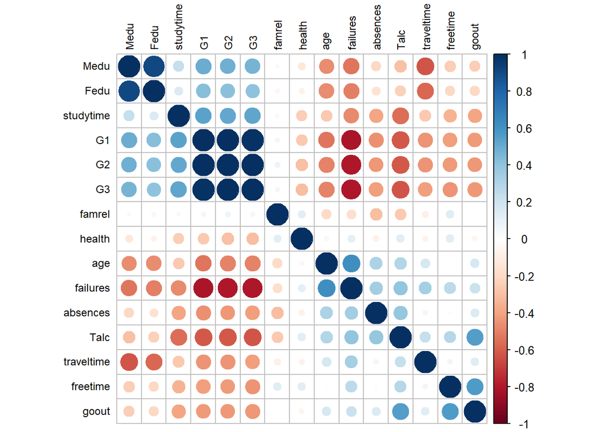

|  | age | Medu | Fedu | traveltime | studytime | failures | famrel | freetime | goout | health | absences | G1 | G2 | G3 | Talc |
| --- | --- | --- | --- | --- | --- | --- | --- | --- | --- | --- | --- | --- | --- | --- | --- |
| age | 1.0000000 | -0.1078318 | -0.1210505 | 0.0344900 | -0.0084151 | 0.3199679 | -0.0205595 | -0.0049103 | 0.1128046 | -0.0087501 | 0.1499982 | -0.1743222 | -0.1071191 | -0.1065054 | 0.1294243 |
| Medu | -0.1078318 | 1.0000000 | 0.6474766 | -0.2650790 | 0.0970058 | -0.1722103 | 0.0244206 | -0.0196863 | 0.0095365 | 0.0046141 | -0.0085775 | 0.2604723 | 0.2640353 | 0.2401508 | -0.0127472 |
| Fedu | -0.1210505 | 0.6474766 | 1.0000000 | -0.2082880 | 0.0503996 | -0.1659150 | 0.0202559 | 0.0068406 | 0.0276897 | 0.0449098 | 0.0298587 | 0.2175007 | 0.2251389 | 0.2117997 | 0.0151685 |
| traveltime | 0.0344900 | -0.2650790 | -0.2082880 | 1.0000000 | -0.0631539 | 0.0977298 | -0.0095212 | 0.0009367 | 0.0574542 | -0.0482612 | -0.0081491 | -0.1541196 | -0.1544889 | -0.1271730 | 0.0881705 |
| studytime | -0.0084151 | 0.0970058 | 0.0503996 | -0.0631539 | 1.0000000 | -0.1474405 | -0.0041271 | -0.0688292 | -0.0754422 | -0.0564327 | -0.1183894 | 0.2608754 | 0.2404980 | 0.2497887 | -0.1820019 |
| failures | 0.3199679 | -0.1722103 | -0.1659150 | 0.0977298 | -0.1474405 | 1.0000000 | -0.0626452 | 0.1089946 | 0.0450778 | 0.0355882 | 0.1227788 | -0.3842105 | -0.3857822 | -0.3933155 | 0.1074038 |
| famrel | -0.0205595 | 0.0244206 | 0.0202559 | -0.0095212 | -0.0041271 | -0.0626452 | 1.0000000 | 0.1292157 | 0.0897066 | 0.1095592 | -0.0895337 | 0.0487946 | 0.0895878 | 0.0633611 | -0.0904517 |
| freetime | -0.0049103 | -0.0196863 | 0.0068406 | 0.0009367 | -0.0688292 | 0.1089946 | 0.1292157 | 1.0000000 | 0.3463518 | 0.0845264 | -0.0187160 | -0.0944966 | -0.1066779 | -0.1227049 | 0.1251462 |
| goout | 0.1128046 | 0.0095365 | 0.0276897 | 0.0574542 | -0.0754422 | 0.0450778 | 0.0897066 | 0.3463518 | 1.0000000 | -0.0157411 | 0.0853738 | -0.0740526 | -0.0794692 | -0.0876407 | 0.3265279 |
| health | -0.0087501 | 0.0046141 | 0.0449098 | -0.0482612 | -0.0564327 | 0.0355882 | 0.1095592 | 0.0845264 | -0.0157411 | 1.0000000 | -0.0302349 | -0.0516474 | -0.0821791 | -0.0988512 | 0.0870741 |
| absences | 0.1499982 | -0.0085775 | 0.0298587 | -0.0081491 | -0.1183894 | 0.1227788 | -0.0895337 | -0.0187160 | 0.0853738 | -0.0302349 | 1.0000000 | -0.1471492 | -0.1247449 | -0.0913791 | 0.1840144 |
| G1 | -0.1743222 | 0.2604723 | 0.2175007 | -0.1541196 | 0.2608754 | -0.3842105 | 0.0487946 | -0.0944966 | -0.0740526 | -0.0516474 | -0.1471492 | 1.0000000 | 0.8649816 | 0.8263871 | -0.1994658 |
| G2 | -0.1071191 | 0.2640353 | 0.2251389 | -0.1544889 | 0.2404980 | -0.3857822 | 0.0895878 | -0.1066779 | -0.0794692 | -0.0821791 | -0.1247449 | 0.8649816 | 1.0000000 | 0.9185480 | -0.1990559 |
| G3 | -0.1065054 | 0.2401508 | 0.2117997 | -0.1271730 | 0.2497887 | -0.3933155 | 0.0633611 | -0.1227049 | -0.0876407 | -0.0988512 | -0.0913791 | 0.8263871 | 0.9185480 | 1.0000000 | -0.2144785 |
| Talc | 0.1294243 | -0.0127472 | 0.0151685 | 0.0881705 | -0.1820019 | 0.1074038 | -0.0904517 | 0.1251462 | 0.3265279 | 0.0870741 | 0.1840144 | -0.1994658 | -0.1990559 | -0.2144785 | 1.0000000 |

Like with the categorical variables, we also found the p-values and R-squared values for each numerical variable model, so that we could also look at the correlations more concretely.

| Variable | P_Value | R_Squared | log_P_Value | log_R_Squared | squared_P_Value | squared_R_Squared |
| --- | --- | --- | --- | --- | --- | --- |
| age | 0.0009508 | 0.0167507 | 0.0011113 | 0.0163113 | 0.0008047 | 0.0172209 |
| Medu | 0.7458414 | 0.0001625 | 0.6233699 | 0.0003764 | 0.9116549 | 0.0000190 |
| Fedu | 0.6997181 | 0.0002301 | 0.7772329 | 0.0001252 | 0.7009374 | 0.0002281 |
| traveltime | 0.0246891 | 0.0077740 | 0.0538734 | 0.0057323 | 0.0119800 | 0.0097186 |
| studytime | 0.0000031 | 0.0331247 | 0.0000002 | 0.0415531 | 0.0001335 | 0.0223175 |
| failures | 0.0061661 | 0.0115356 | 0.7983937 | 0.0006689 | 0.0276176 | 0.0074766 |
| famrel | 0.0211898 | 0.0081815 | 0.0154816 | 0.0090245 | 0.0372151 | 0.0066914 |
| freetime | 0.0014003 | 0.0156616 | 0.0140863 | 0.0092796 | 0.0003111 | 0.0199107 |
| goout | 0.0000000 | 0.1066205 | 0.0000000 | 0.0899370 | 0.0000000 | 0.1118804 |
| health | 0.0265417 | 0.0075819 | 0.0416204 | 0.0063995 | 0.0226275 | 0.0080062 |
| absences | 0.0000024 | 0.0338613 | 0.0000553 | 0.0395895 | 0.0000527 | 0.0249697 |
| G1 | 0.0000003 | 0.0397866 | 0.0000003 | 0.0399520 | 0.0000002 | 0.0409174 |
| G2 | 0.0000003 | 0.0396232 | 0.0000004 | 0.0394782 | 0.0000003 | 0.0395557 |
| G3 | 0.0000000 | 0.0460010 | 0.0000000 | 0.0556198 | 0.0000000 | 0.0457386 |

| sqrt_P_Value | sqrt_R_Squared | inv_P_Value | inv_R_Squared | cubic_P_Value | cubic_R_Squared | zscore_P_Value | zscore_R_Squared |
| --- | --- | --- | --- | --- | --- | --- | --- |
| 0.0010292 | 0.0165273 | 0.0012865 | 0.0158996 | 0.0006734 | 0.0177240 | 0.0009508 | 0.0167507 |
| 0.5929696 | 0.0004419 | 0.4112083 | 0.0010538 | 0.9613381 | 0.0000036 | 0.7458414 | 0.0001625 |
| 0.5179397 | 0.0006463 | 0.6456573 | 0.0003305 | 0.6435257 | 0.0003312 | 0.6997181 | 0.0002301 |
| 0.0369859 | 0.0067076 | 0.0965937 | 0.0042614 | 0.0081407 | 0.0107726 | 0.0246891 | 0.0077740 |
| 0.0000006 | 0.0379086 | 0.0000000 | 0.0451820 | 0.0030454 | 0.0134891 | 0.0000031 | 0.0331247 |
| 0.0034691 | 0.0131268 | 0.8278266 | 0.0004850 | 0.0622366 | 0.0053634 | 0.0061661 | 0.0115356 |
| 0.0170597 | 0.0087629 | 0.0202207 | 0.0083067 | 0.0622011 | 0.0053648 | 0.0211898 | 0.0081815 |
| 0.0042019 | 0.0125951 | 0.1187239 | 0.0037579 | 0.0001751 | 0.0215443 | 0.0014003 | 0.0156616 |
| 0.0000000 | 0.0998906 | 0.0000000 | 0.0641658 | 0.0000000 | 0.1107207 | 0.0000000 | 0.1066205 |
| 0.0320047 | 0.0070873 | 0.0779091 | 0.0047959 | 0.0228403 | 0.0079813 | 0.0265417 | 0.0075819 |
| 0.0000626 | 0.0244764 | 0.0020587 | 0.0233174 | 0.0040759 | 0.0126794 | 0.0000024 | 0.0338613 |
| 0.0000019 | 0.0344291 | 0.0000035 | 0.0327740 | 0.0000005 | 0.0382419 | 0.0000003 | 0.0397866 |
| 0.0000062 | 0.0311213 | 0.0000017 | 0.0351170 | 0.0000014 | 0.0354080 | 0.0000003 | 0.0396232 |
| 0.0000023 | 0.0339348 | 0.0000012 | 0.0367376 | 0.0000002 | 0.0408816 | 0.0000000 | 0.0460010 |

Above we have the p-values and r-squared for multiple possible transformations of the numerical variables. Below we will print the best versions of each:

| Variable | Best_P_Value | Best_P_Value_Type | Best_R_Squared | Best_R_Squared_Type |
| --- | --- | --- | --- | --- |
| age | 0.0006734 | cubic | 0.0177240 | cubic |
| Medu | 0.4112083 | inv | 0.0010538 | inv |
| Fedu | 0.5179397 | sqrt | 0.0006463 | sqrt |
| traveltime | 0.0081407 | cubic | 0.0107726 | cubic |
| studytime | 0.0000000 | inv | 0.0451820 | inv |
| failures | 0.0034691 | sqrt | 0.0131268 | sqrt |
| famrel | 0.0154816 | log | 0.0090245 | log |
| freetime | 0.0001751 | cubic | 0.0215443 | cubic |
| goout | 0.0000000 | squared | 0.1118804 | squared |
| health | 0.0226275 | squared | 0.0080062 | squared |
| absences | 0.0000024 | zscore | 0.0395895 | log |
| G1 | 0.0000002 | squared | 0.0409174 | squared |
| G2 | 0.0000003 | zscore | 0.0396232 | zscore |
| G3 | 0.0000000 | log | 0.0556198 | log |

### Regression

Based on all of the visuals and statistics, we attempted to make a model to predict the total alcohol consumption rating.

##### Figure 5. Regression Summary

**Forward Stepwise Regression Attempt**

```
##
## Call:
## lm(formula = paste(response, "~", paste(preds, collapse = " + ")),
##     data = l)
##
## Coefficients:
##      (Intercept)             goout              sexM          absences
##         0.214211          0.245754          0.521196          0.025157
##           famrel        reasonhome       reasonother  reasonreputation
##        -0.144336          0.129436          0.312408          0.014732
##              age        Fjobhealth         Fjobother      Fjobservices
##         0.054331          0.189319          0.127986          0.307964
##      Fjobteacher            health         studytime        nurseryyes
##        -0.082254          0.049503         -0.085577         -0.149131
##         addressU        famsizeLE3          PstatusT    guardianmother
##        -0.103722          0.136357          0.126897         -0.146383
##    guardianother        Mjobhealth         Mjobother      Mjobservices
##        -0.004319         -0.261948         -0.094937         -0.001915
##      Mjobteacher       romanticyes
##         0.085296          0.089865
```

**Hypothetical Best Model**

```
##
## Call:
## lm(formula = Talc ~ goout + sex + absences + famrel + reason +
##     age + Fjob + Mjob + health + studytime + nursery + address +
##     famsize + Pstatus + guardian + romantic, data = d3)
##
## Residuals:
##     Min      1Q  Median      3Q     Max
## -2.3726 -0.4986 -0.1437  0.3326  3.0187
##
## Coefficients:
##                    Estimate Std. Error t value Pr(>|t|)
## (Intercept)       8.062e-01  2.867e-01   2.812 0.005085 **
## goout             3.863e-02  4.169e-03   9.265  < 2e-16 ***
## sexM              5.029e-01  6.774e-02   7.424 3.75e-13 ***
## absences          2.430e-02  7.058e-03   3.442 0.000615 ***
## famrel           -1.395e-01  3.319e-02  -4.202 3.04e-05 ***
## reasonhome        1.479e-01  8.189e-02   1.806 0.071359 .
## reasonother       3.176e-01  1.056e-01   3.007 0.002743 **
## reasonreputation  2.305e-02  8.511e-02   0.271 0.786574
## age               6.393e-05  3.217e-05   1.987 0.047333 *
## Fjobhealth        1.833e-01  2.151e-01   0.852 0.394450
## Fjobother         1.326e-01  1.309e-01   1.013 0.311525
## Fjobservices      3.132e-01  1.381e-01   2.268 0.023682 *
## Fjobteacher      -7.584e-02  1.872e-01  -0.405 0.685542
## Mjobhealth       -2.497e-01  1.414e-01  -1.765 0.078030 .
## Mjobother        -1.023e-01  8.659e-02  -1.181 0.238108
## Mjobservices     -9.855e-03  1.015e-01  -0.097 0.922683
## Mjobteacher       9.129e-02  1.243e-01   0.735 0.462812
## health            4.658e-02  2.231e-02   2.088 0.037201 *
## studytime         3.134e-01  1.225e-01   2.559 0.010743 *
## nurseryyes       -1.511e-01  7.919e-02  -1.908 0.056893 .
## addressU         -9.591e-02  7.053e-02  -1.360 0.174345
## famsizeLE3        1.380e-01  7.128e-02   1.936 0.053309 .
## PstatusT          1.120e-01  1.007e-01   1.113 0.266351
## guardianmother   -1.552e-01  7.666e-02  -2.025 0.043301 *
## guardianother    -1.017e-02  1.544e-01  -0.066 0.947525
## romanticyes       8.616e-02  6.636e-02   1.298 0.194612
## ---
## Signif. codes:  0 '***' 0.001 '**' 0.01 '*' 0.05 '.' 0.1 ' ' 1
##
## Residual standard error: 0.7861 on 623 degrees of freedom
## Multiple R-squared:  0.317,  Adjusted R-squared:  0.2896
## F-statistic: 11.57 on 25 and 623 DF,  p-value: < 2.2e-16
```

G1, G2, and G3 were excluded from being independent variables as they are other dependent variables (it wouldnt make sense for a final grade to influence drinking during the semester, for example)

In theory, one of the best models available with the data is the model above (Adjusted R-squared of 0.2896). As we can see, the p-value is very low, but so is the adjusted R-squared. This means that although the model is a good predictor, the variability in the data cannot be explained by the model. Unfortunately, another issue here is overfitting. In order to combat this, we will make a new model fit on training data and apply it to testing data. This will make the data more generalizable, but will lower our adjusted R-squared (on the training data) further.

**Making a model with training data and applying to testing data**

```r
d3 = read.csv("student-por.csv")
d3$Talc <- ((5/7) * d3$Dalc) + ((2/7) * d3$Walc)

set.seed(123)

# Training and testing data
train_indices <- sample(seq_len(nrow(d3)), 0.8 * nrow(d3))  # 80% for training
test_indices <- setdiff(seq_len(nrow(d3)), train_indices)  # Remaining for testing
train_data <- d3[train_indices, ]
test_data <- d3[test_indices, ]

train_data$goout = train_data$goout^2
train_data$famrel = log(train_data$famrel)
train_data$age = as.factor(train_data$age)

# Fit the linear model on the training data
lmod_train <- lm(Talc ~ goout + sex + absences + famrel + reason + age +
                 health + famsize,
                 data = train_data)

summary(lmod_train)
```

```
##
## Call:
## lm(formula = Talc ~ goout + sex + absences + famrel + reason +
##     age + health + famsize, data = train_data)
##
## Residuals:
##     Min      1Q  Median      3Q     Max
## -1.8808 -0.5042 -0.1564  0.2919  3.0091
##
## Coefficients:
##                   Estimate Std. Error t value Pr(>|t|)
## (Intercept)       1.356349   0.183865   7.377 6.75e-13 ***
## goout             0.032290   0.004554   7.090 4.58e-12 ***
## sexM              0.546771   0.070422   7.764 4.65e-14 ***
## absences          0.015978   0.007599   2.103  0.03600 *
## famrel           -0.496173   0.104865  -4.732 2.90e-06 ***
## reasonhome        0.134404   0.087761   1.531  0.12628
## reasonother       0.326733   0.115232   2.835  0.00476 **
## reasonreputation -0.021821   0.088916  -0.245  0.80624
## age16            -0.084178   0.102939  -0.818  0.41389
## age17             0.132406   0.103150   1.284  0.19986
## age18             0.053664   0.110922   0.484  0.62874
## age19             0.210818   0.180701   1.167  0.24390
## age20             0.212384   0.354490   0.599  0.54936
## age21             0.840097   0.553976   1.516  0.13003
## age22             2.515604   0.787237   3.195  0.00148 **
## health            0.054130   0.024669   2.194  0.02868 *
## famsizeLE3        0.163106   0.075168   2.170  0.03048 *
## ---
## Signif. codes:  0 '***' 0.001 '**' 0.01 '*' 0.05 '.' 0.1 ' ' 1
##
## Residual standard error: 0.7655 on 502 degrees of freedom
## Multiple R-squared:  0.2891, Adjusted R-squared:  0.2665
## F-statistic: 12.76 on 16 and 502 DF,  p-value: < 2.2e-16
```

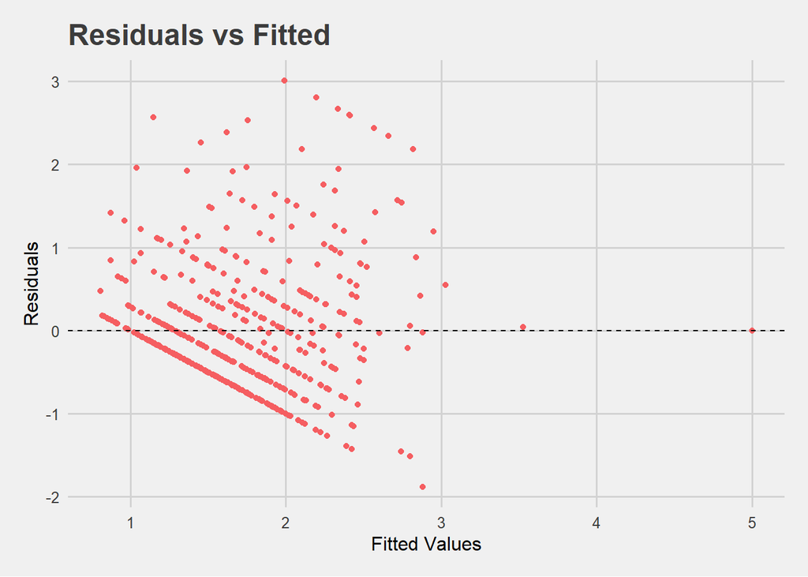

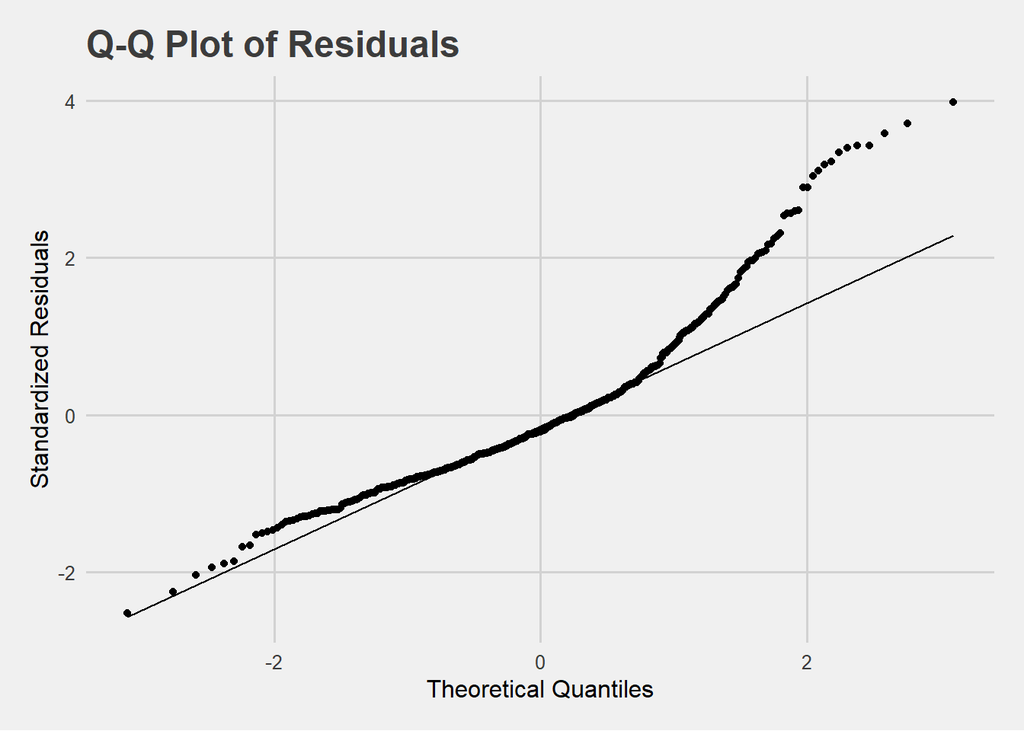

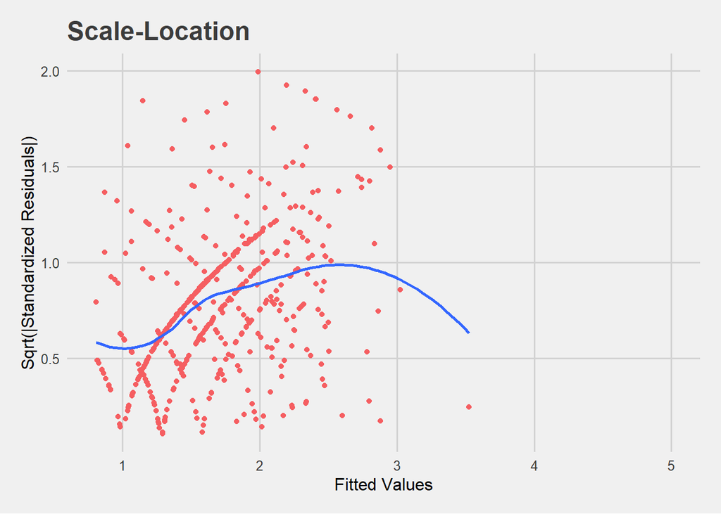

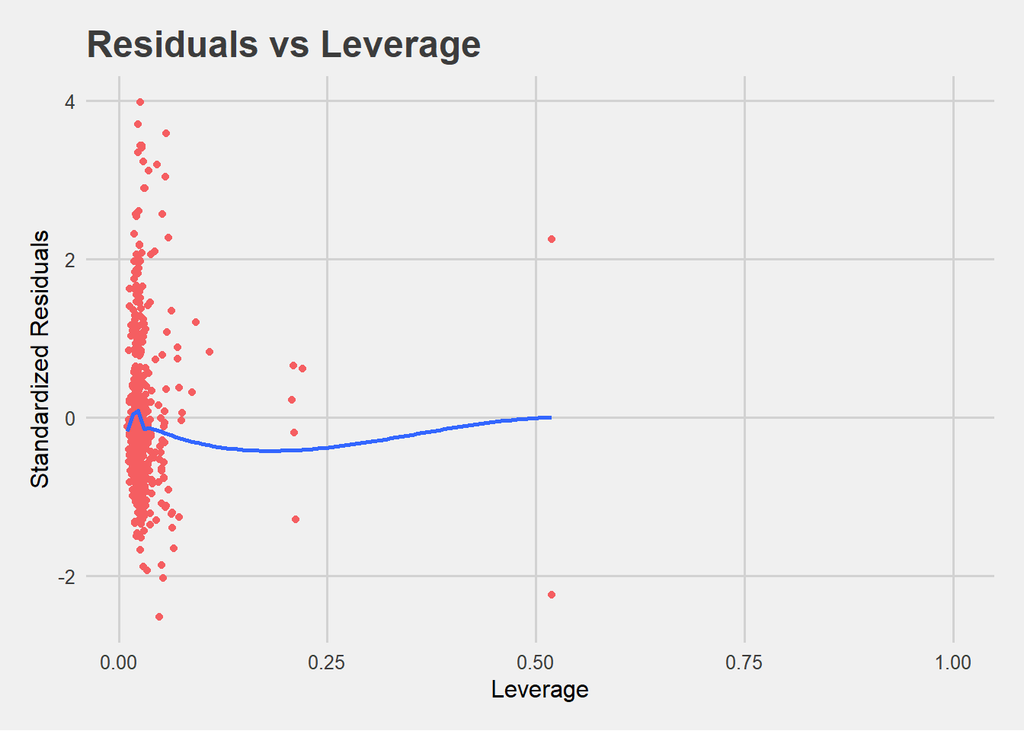

The model and plots above are for the training data. We can see that the Adjusted R-squared has lowered slightly from the highest possible one, but is still close. There are now far fewer variables in order to discourage overfitting. The only remaining variables are goout, sex, absences, famrel, reason, age, health, and famsize.

The plots show that the models are not ideal. None of the typical assumptions of the model can be made confidently here. Linearity could potentially be satisfied, though there is a clear pattern in the fitted values which dissuades us from doing so. Normality cannot be satisfied completely, as the residuals of the model stray far from the model at larger quantiles in the data. Homoscedasticity cant be satisfied completely either, as there are clear patterns in the data seen in the plot. Finally, the residuals vs leverage graph shows how a lot of the data strays from the line, though only a few points exist with very high leverage. Although these issues exist, this is the best that can be done with this dataset.

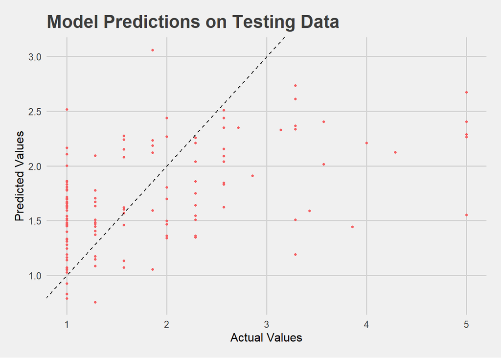

```
## The root mean square error is: 0.9355783
```

Overall, these findings all seem to be interesting, and further explorations of data should be done to determine these relationships more conclusively.

### Analyzing the Grades

We also wanted to do a quick analysis on how grades are affected by the total alcohol consumption

##### Figure 6. Scatterplot Analysis on Grades

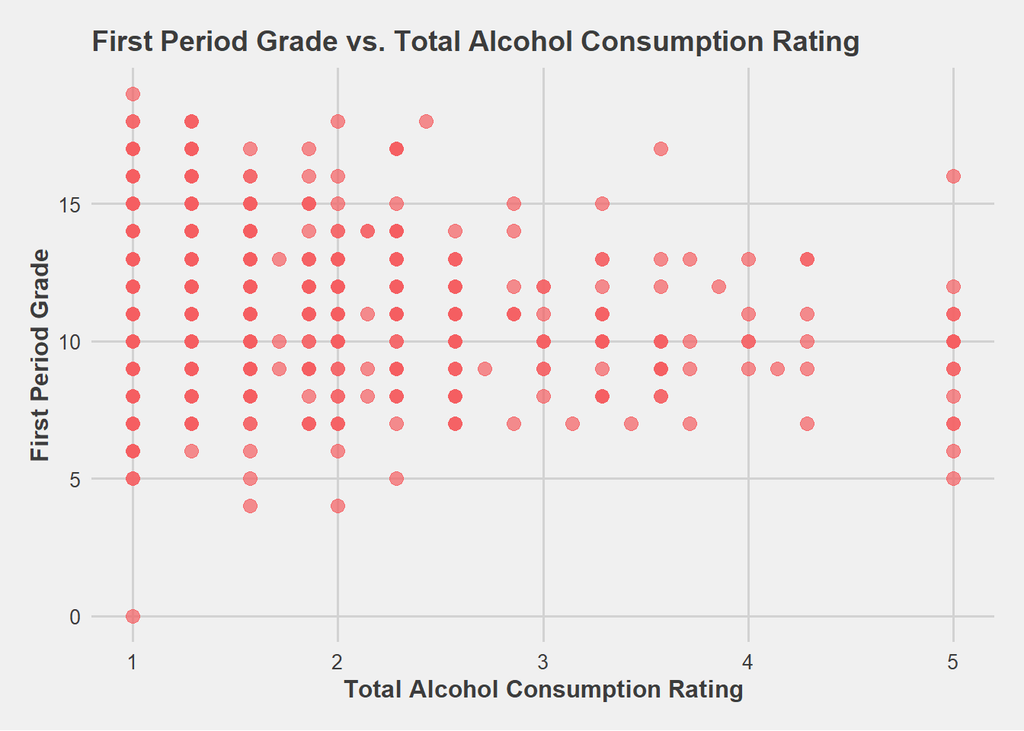

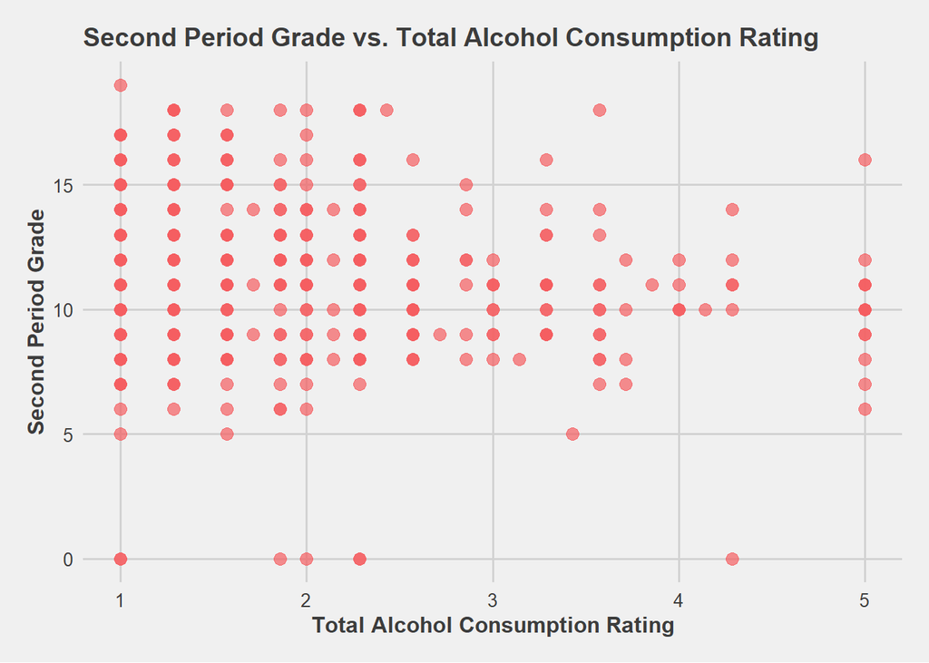

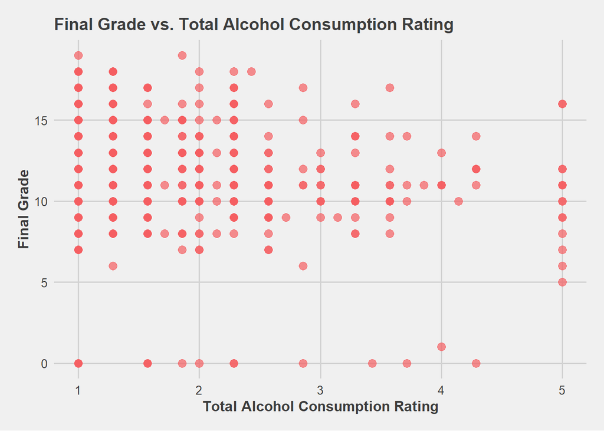

It is difficult to make out much of a difference between all three grading points. If any difference exists, the intercept seems to slightly increase from G1 to G2 to G3, and as a result the slope of Talc seems to go slightly more negative from G1 to G2 to G3. In order to check for this, we can make simple linear regressions for all 3.

##### Figure 7. Regression Analysis on Grades

```r
lmod4 <- lm(G1~Talc, data=d3)
summary(lmod4)
```

```
##
## Call:
## lm(formula = G1 ~ Talc, data = d3)
##
## Residuals:
##      Min       1Q   Median       3Q      Max
## -11.8245  -1.8245   0.0981   2.0981   7.1755
##
## Coefficients:
##             Estimate Std. Error t value Pr(>|t|)
## (Intercept)  12.4116     0.2223  55.838   <2e-16 ***
## Talc         -0.5871     0.1134  -5.178    3e-07 ***
## ---
## Signif. codes:  0 '***' 0.001 '**' 0.01 '*' 0.05 '.' 0.1 ' ' 1
##
## Residual standard error: 2.692 on 647 degrees of freedom
## Multiple R-squared:  0.03979,    Adjusted R-squared:  0.0383
## F-statistic: 26.81 on 1 and 647 DF,  p-value: 3.003e-07
```

```r
lmod5 <- lm(G2~Talc, data=d3)
summary(lmod5)
```

```
##
## Call:
## lm(formula = G2 ~ Talc, data = d3)
##
## Residuals:
##      Min       1Q   Median       3Q      Max
## -12.0207  -1.8430  -0.0207   1.7788   7.5782
##
## Coefficients:
##             Estimate Std. Error t value Pr(>|t|)
## (Intercept)  12.6425     0.2359  53.586  < 2e-16 ***
## Talc         -0.6218     0.1204  -5.167 3.18e-07 ***
## ---
## Signif. codes:  0 '***' 0.001 '**' 0.01 '*' 0.05 '.' 0.1 ' ' 1
##
## Residual standard error: 2.858 on 647 degrees of freedom
## Multiple R-squared:  0.03962,    Adjusted R-squared:  0.03814
## F-statistic: 26.69 on 1 and 647 DF,  p-value: 3.179e-07
```

```r
lmod6 <- lm(G3~Talc, data=d3)
summary(lmod6)
```

```
##
## Call:
## lm(formula = G3 ~ Talc, data = d3)
##
## Residuals:
##      Min       1Q   Median       3Q      Max
## -12.4443  -1.4892  -0.0198   1.7679   7.1924
##
## Coefficients:
##             Estimate Std. Error t value Pr(>|t|)
## (Intercept)  13.1872     0.2607  50.578  < 2e-16 ***
## Talc         -0.7429     0.1330  -5.585 3.43e-08 ***
## ---
## Signif. codes:  0 '***' 0.001 '**' 0.01 '*' 0.05 '.' 0.1 ' ' 1
##
## Residual standard error: 3.158 on 647 degrees of freedom
## Multiple R-squared:  0.046,  Adjusted R-squared:  0.04453
## F-statistic:  31.2 on 1 and 647 DF,  p-value: 3.434e-08
```

As expected, our previous theory of increasing intercepts and decreasing Talc was correct. In all three cases, the p-values of the models are fairly low. Unsurprisingly in all three cases the Adjusted R-squared values are also very low, as evidenced by the variability in the scatterplots.

All in all, this was a fun experiment on regression analysis, and further studies can be done with our findings by looking into more datasets.